# Bacterial species classification and prediction with MSclassifR package

Alexandre Godmer, Quentin Giai Gianetto

2022-04-21

## 1. Introduction

`MSclassifR` is a R package dedicated for Automated classification of mass-spectra with machine learning methods.It was developed with the aim of identifying very similar species or phenotypes of bacteria from mass spectra obtained by Matrix Assisted Laser Desorption Ionisation - Time Of Flight Mass Spectrometry (MALDI-TOF MS). However, the different functions of this package can also be used to classify other categories associated to mass spectra; or from mass spectra obtained with other mass spectrometry techniques. It includes easy-to-use functions for pre-processing mass spectra, functions to determine discriminant mass-over-charge values (m/z) from a library of mass spectra corresponding to different categories, and functions to predict the category (species, phenotypes, etc.) associated to a mass spectrum from a list of selected mass-over-charge values.

In this vignette, we search to discriminate five species of the genus *Ecrobia* by MALDI-TOF mass spectrometry with a data set of 55 mass spectra (Lasch *et al.* (2016)) using `MSclassifR` package. The raw data concerning from a research paper (Wilke *et al.*, 2020) were downloaded from this [link](https://www.ebi.ac.uk/pride/archive/projects/PXD019310).

## 2. Install packages

The installation of the `MSclassifR` package requires the installation of packages from `Bioconductor`, so you you might have to install the latest version of the `BiocManager` package. The `MSclassifR` package imports the other necessary packages from the CRAN. In addition, it is recommended to install the latest version of R or versions >= 4.0.

- Install `MSclassifR` using the following code:

```
## install BiocManager if not installed
    if (!require("BiocManager", quietly = TRUE))
        install.packages("BiocManager")

## Install the mixOmics and multtest packages from Bioconductor
   BiocManager::install(c("multtest","mixOmics"))

## Install MSclassifR package
install.packages("MSclassifR")
```

- Check after install the `MSclassifR` package:

```r
## For spectral easy spectral treatment and machine learning
require(MSclassifR)
```

- To continue this vignette, we need the `MALDIquantForeign`, `MALDIquant` and `caret` packages from the CRAN. The installation is possible with the command `install.packages()`.

```r
## time measurement
start_time <- Sys.time()

## For additional spectral treatment functions
require(MALDIquantForeign)
require(MALDIquant)

## For additional machine learning functions
require(caret)
```

## 3. Import spectra and metadata

For this vignette, we will load mass spectra and their respective metadata from a public repository on GitHub.

```r
## url for load the  MS data
MSdataE <- "https://agodmer.github.io/MSData/Ecrobia/MassSpectra_Ecrobia.Rdata"
MSMetadataE <- "https://agodmer.github.io/MSData/Ecrobia/metaData_Ecrobia.Rdata"
## Load mass spectra
### Mass spectra
load(url(MSdataE))
### Metadata
load(url(MSMetadataE))
```

If you want to use your own data with .flex format from Bruker MALDI-TOF MS, you could use `importBrukerFlex` from `MALDIquantForeign package`. Of note, you will have to create your own corresponding metadata as a data frame in this case.

```r
## for data .flex format import
#MyBrukerFlexspectra <- MALDIquantForeign::importBrukerFlex("YourPathway")
```

## 4. Plotting mass spectra

It can be useful to inspect the spectra visually before starting the analysis. This step allows eliminating poor quality spectra.

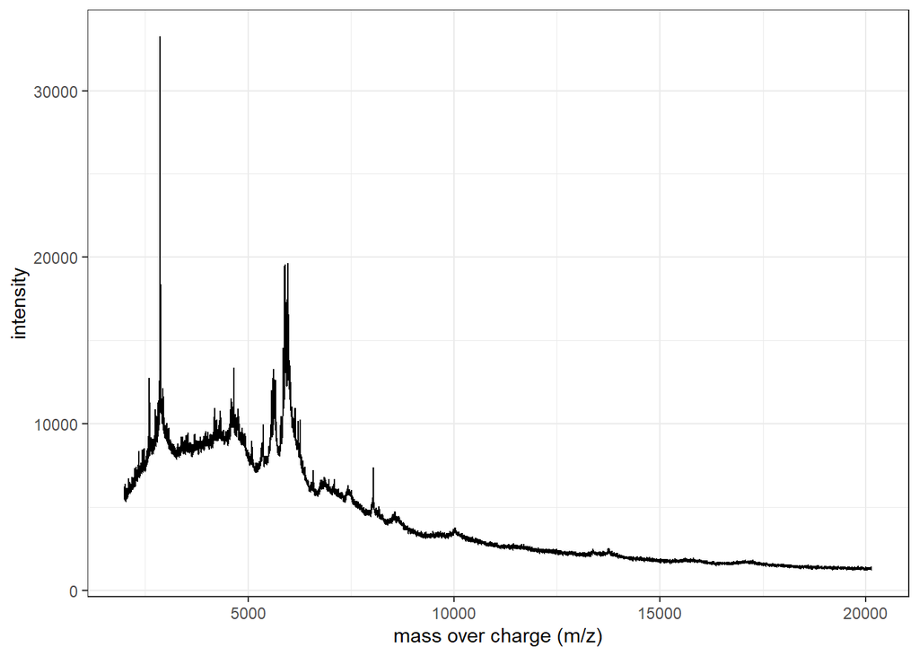

```r
## Visual quality control
MSclassifR::PlotSpectra(SpectralData=MassSpectra_Ecrobia[[1]])
```

## 5. Signal processing and peaks detection

```r
## Signal processing
spectra <- MSclassifR::SignalProcessing(MassSpectra_Ecrobia)
## Peaks detection
peaks <- MSclassifR::PeakDetection(spectra, labels = metaData_Ecrobia$Number_strain)
```

You can plot the spectral processing performed and the peaks selected (black crosses).

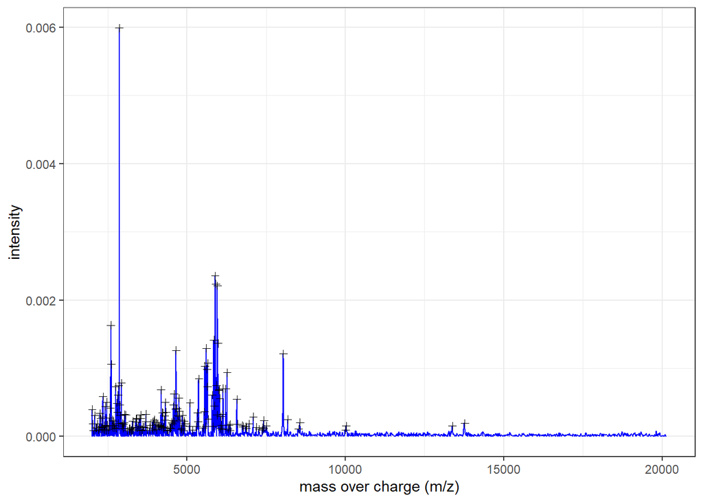

```r
## Inspect spectra after signal processing
MSclassifR::PlotSpectra(SpectralData=spectra[[1]],Peaks=peaks[[1]],col_spec="blue",col_peak="black")
```

At this step, we create an intensity matrix with m/z values in columns and sample names in rows data with the `intensityMatrix` function in `MALDIquant` package (Gibb and Strimmer (2012)).

```r
## Perfom an Intensity Matrix with spectra data
IntMat <- MALDIquant::intensityMatrix(peaks)

## Rows are named according to selected metadata
rownames(IntMat) <-  paste(metaData_Ecrobia$Strain_name_spot, metaData_Ecrobia$Number_strain)

## Remove "NA" in the intensityMatrix
IntMat[is.na(IntMat)] <- 0

## Normalise peaks according to the maximum intensity
## Create basic function
norma<-function(x) x/(max(x))
## Apply this function
IntMat <- apply(IntMat,1,norma)

## Transpose Matrix for statistical analysis and named X
X <- t(IntMat)
Y <- factor(metaData_Ecrobia$Species)
```

The dataset is splitted it into training (70%) and test (30%) datasets using `caret`package Kuhn (2008) and the `createDataPartition` function for machine learning step.

```r
set.seed(123) # For reproductibility
## Split data to tune the model according train set

## Index creation with p = 0,7
Index_skfold <- caret::createDataPartition(Y, p = 0.7, list=FALSE)

## Train set creation
X_train <- X[Index_skfold,]
Y_train <- Y[Index_skfold]

## Test set creation
X_test <- X[-Index_skfold,]
Y_test <- Y[-Index_skfold]

## Format Y_test as a factor for analysis
Y_testb <- gsub(" ", ".",Y_test)
```

## 6. Variable selection

The selection of discriminant mass-over-charge values can be performed with several methods proposed in the `SelectionVar` function of our `MSclassifR` package. The `RFERF` method uses the Recursive Feature Elimination (RFE) algorithm coupled with Random Forests (RF); the `RFEGlmnet` method uses RFE coupled with Logistic regression; the `sPLSDA` method uses sparse partial least squares discriminant analysis (sPLS-DA) (Rohart F *et al.* (2017)). The sPLSDA method selects variables from the ones kept in latent components of the model using an automatic choice of the number of components; the `VSURF` method uses RF with the `VSURF` function and package (Genuer *et al.* (2015)).

For this example, we used a k-fold cross validation (k = 2) with 5 to 70 variables. The `VSURF` method performs three steps variables selection : thresholding step, interpretation step and prediction step (Genuer *et al.* (2015)).

```r
## a. using RFE and Random forest model
set.seed(2) # for  reproducibility
a <- SelectionVar(X_train,
                  Y_train,
                  MethodSelection = c("RFERF"),
                  MethodValidation = c("cv"),
                  NumberCV = 2,
                  PreProcessing = c("center","scale","nzv","corr"),
                  Sizes = c(5:70))


## b. using RFE and Random forest model
set.seed(2) # for  reproducibility
b <- SelectionVar(X_train,
                  Y_train,
                  MethodSelection = c("RFEGlmnet") ,
                  MethodValidation = c("cv"),
                  NumberCV = 2,
                  PreProcessing = c("center","scale","nzv","corr"),
                  Sizes = c(5:70))


## c. using sPLDA method
set.seed(2) # for  reproducibility
c <- SelectionVar(X_train,
                  Y_train,
                  MethodSelection = c("sPLSDA"),
                  MethodValidation = c("cv"),
                  NumberCV = 2,
                  PreProcessing = c("scale","nzv"),
                  Sizes = c(5:70))
```

```r
## d. using VSURF
set.seed(2) # for  reproducibility
d <- SelectionVar(X_train,
                  Y_train,
                  MethodSelection = c("VSURF"))
```

```r
## Keep selected variables in a list
list_moz <- list("RFERF" = a$sel_moz,
                 "RFEglmnet" = b$sel_moz,
                 "sPLSDA" = c$sel_moz,
                 "VSURF" = d$sel_moz)
```

- We can visualize the peaks selected by the `RFERF` with the red dotted lines.

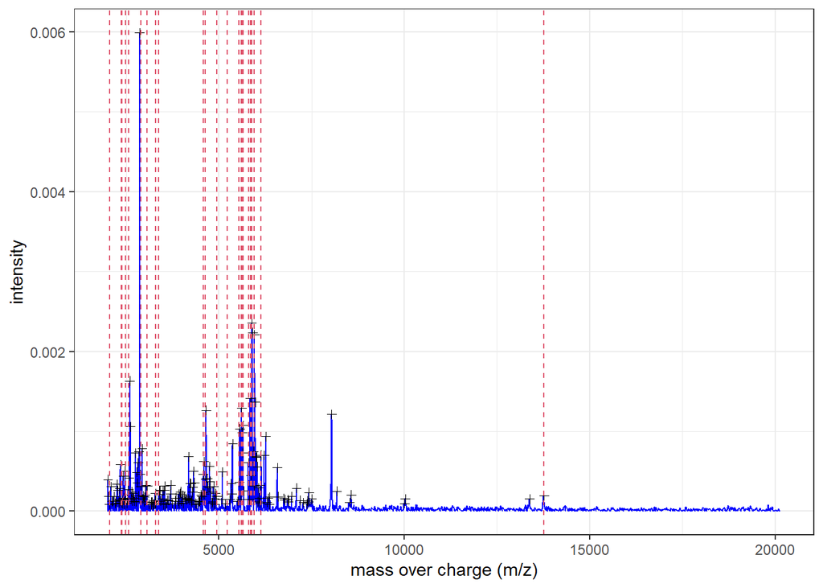

```r
PlotSpectra(SpectralData=spectra[[1]],Peaks=peaks[[1]],
Peaks2=a$sel_moz,col_spec="blue",col_peak="black")
```

- We can visualize the peaks selected by the `RFEglmnet` method with the red dotted lines.

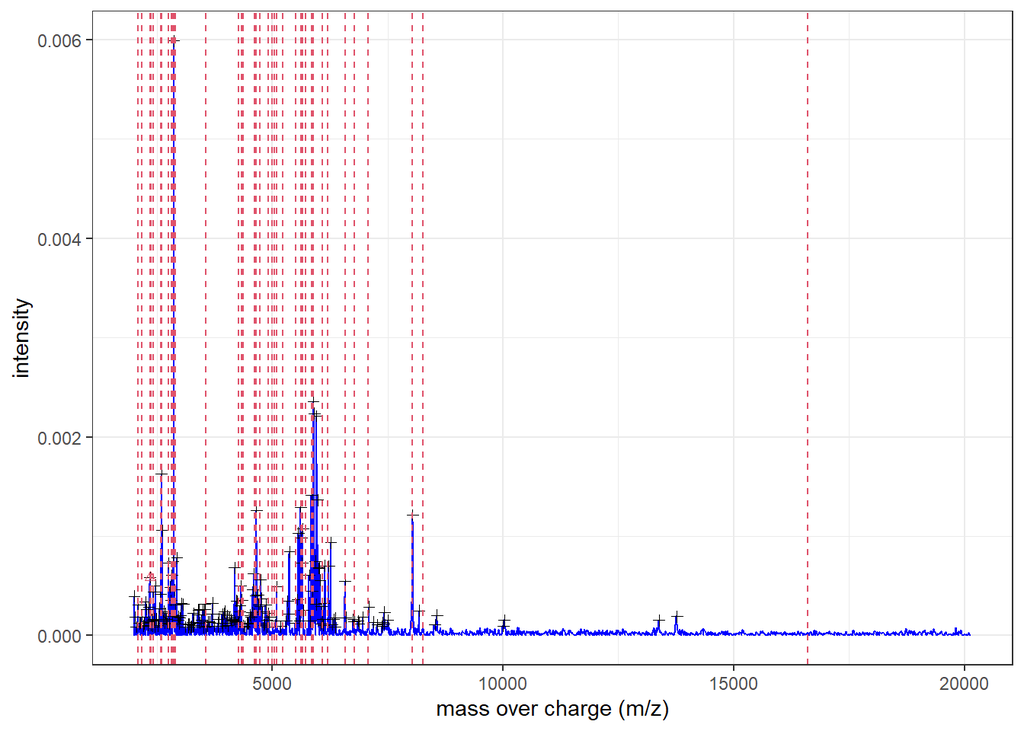

```r
PlotSpectra(SpectralData=spectra[[1]],Peaks=peaks[[1]],
Peaks2=b$sel_moz,col_spec="blue",col_peak="black")
```

- We can visualize the peaks selected by the `sPLSDA` method with the red dotted lines.

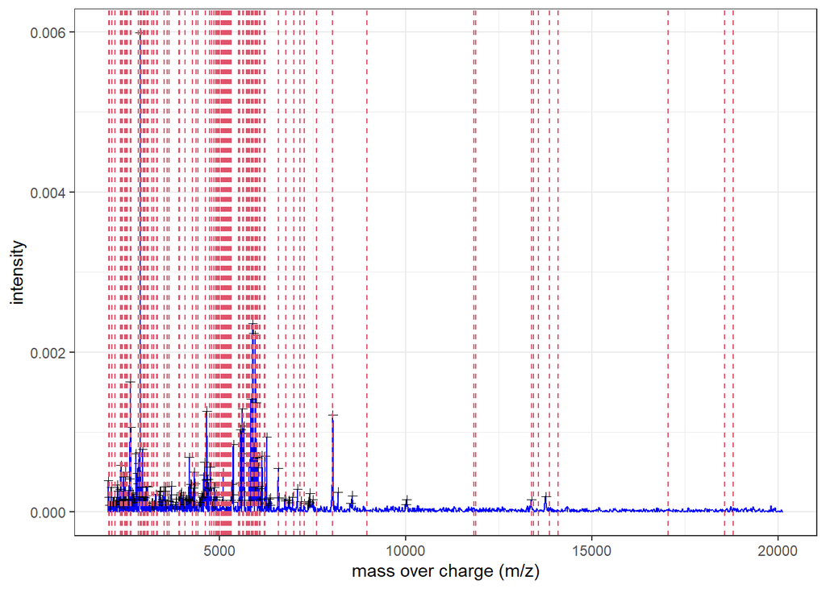

```r
MSclassifR::PlotSpectra(SpectralData=spectra[[1]],Peaks=peaks[[1]],
Peaks2=c$sel_moz,col_spec="blue",col_peak="black")
```

- We can visualize the peaks selected by the `VSURF` method with the red dotted lines.

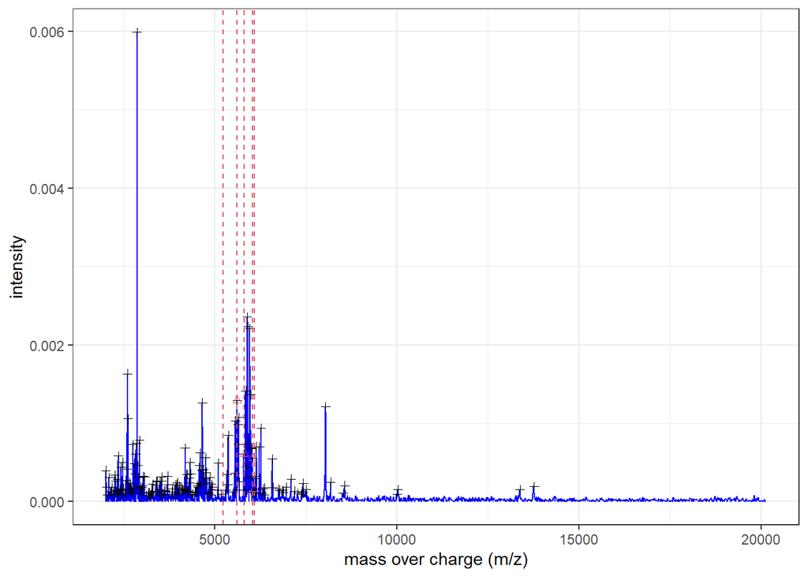

```r
MSclassifR::PlotSpectra(SpectralData=spectra[[1]],Peaks=peaks[[1]],
Peaks2=d$sel_moz,col_spec="blue",col_peak="black")
```

## 7. Estimation of a multinomial logistic regression

With the selected discriminant masses, we can create a prediction model. The `LogReg` function allows estimating a prediction model with k-fold cross validation in order to predict the category to which a mass spectrum belongs. Two main kinds of models can be estimated: linear or nonlinear (with neural networks (`nnet` method), random forests (`rf` method), support vector machines with linear kernel (`svm` method), or eXtreme Gradient Boosting (`xgb` method)). Hyperparameters are randomly searched, except for the eXtreme Gradient Boosting where a grid search is performed.

In this part, we will create different prediction models with discriminant mass-over-charge values previously selected ones using the 4 methods described above.

Each prediction models were estimated with a repeated k-fold cross validation (k = 2, and 2 repeats)in the train data set. Next, the accuracies of estimated models are evaluated on the test data set.

### 7.1 Use the selected variables with RFERF method

```r
## Select variables found with RFERF
sel_moz=a$sel_moz

## linear multinomial regression
model_lm=MSclassifR::LogReg(X=X_train, moz=sel_moz, Y=factor(Y_train), number=2, repeats=2)
#Estimated model:
#model_lm

## nonlinear multinomial regression using neural networks
model_nn=MSclassifR::LogReg(X=X_train, moz=sel_moz, Y=factor(Y_train), number=2, repeats=2, kind="nnet")
#Estimated model:
#model_nn

## nonlinear multinomial regression using random forests
model_rf=MSclassifR::LogReg(X=X_train, moz=sel_moz, Y=factor(Y_train), number=2, repeats=2, kind="rf")
#Estimated model:
#model_rf

## nonlinear multinomial regression using xgboost
model_xgb=MSclassifR::LogReg(X=X_train, moz=sel_moz, Y=factor(Y_train), number = 2, repeats=2, kind="xgb")
#Estimated model:
#model_xgb

## nonlinear multinomial regression using svm
model_svm=MSclassifR::LogReg(X=X_train, moz=sel_moz, Y=factor(Y_train), number=2, repeats=2, kind="svm")
#Estimated model:
#model_svm
```

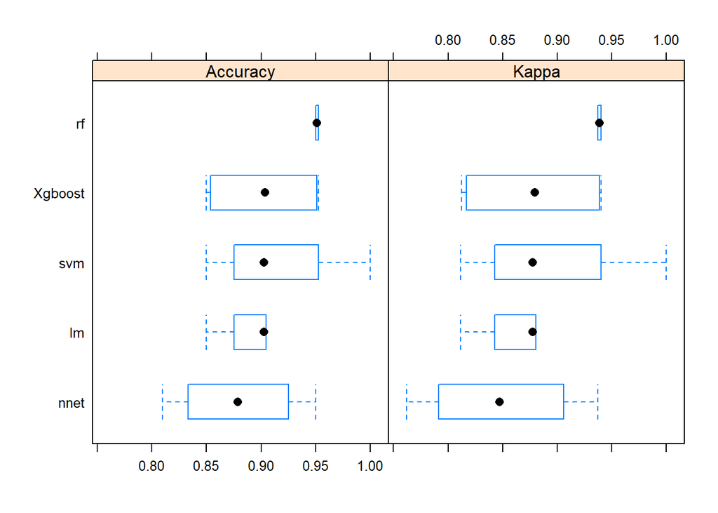

```r
## Keep models in a list
list_model_A <- list("lm" = model_lm$train_mod,
                      "nnet" = model_nn$train_mod,
                      "rf" = model_rf$train_mod,
                      "Xgboost" = model_xgb$train_mod,
                      "svm" = model_svm$train_mod)

## Plot performances of prediction model
model_A <- caret::resamples(list_model_A)
bwplot(model_A)
```

```r
## Probabilities of belonging to each category for the mass spectra on test set
prob_cat=MSclassifR::Predict_LogReg(peaks = peaks[-Index_skfold],
                                    model = list_model_A,
                                    moz = sel_moz)
```

- Estimating accuracies of each method on the test dataset:

```r
## Split table according method used
ResultatsModelA <- split(prob_cat,prob_cat$method)

## Calcul accuracy for each method
DF_A <- data.frame(lapply(ResultatsModelA, function(x)(sum(Y_testb == x[,8])/length(Y_testb))), row.names = "RFERF accuracy")

t(DF_A)
```

```
##             RFERF accuracy
## comb_fisher     0.21428571
## max_vote        0.28571429
## multinom        0.85714286
## nnet            0.85714286
## rf              1.00000000
## svmLinear2      0.07142857
## xgbTree         0.85714286
```

### 7.2 Use the selected variables with RFEGlmnet method

```r
## Select variables found with RFGlmnet
sel_moz=b$sel_moz

## linear multinomial regression
model_lm=MSclassifR::LogReg(X=X_train, moz=sel_moz, Y=factor(Y_train), number=2, repeats=2)
#Estimated model:
#model_lm

## nonlinear multinomial regression using neural networks
model_nn=MSclassifR::LogReg(X=X_train, moz=sel_moz, Y=factor(Y_train), number=2, repeats=2, kind="nnet")
#Estimated model:
#model_nn

## nonlinear multinomial regression using random forests
model_rf=MSclassifR::LogReg(X=X_train, moz=sel_moz, Y=factor(Y_train), number=2, repeats=2, kind="rf")
#Estimated model:
#model_rf

## nonlinear multinomial regression using xgboost
model_xgb=MSclassifR::LogReg(X=X_train, moz=sel_moz, Y=factor(Y_train), number=2, repeats=2, kind="xgb")
#Estimated model:
#model_xgb

## nonlinear multinomial regression using svm
model_svm=MSclassifR::LogReg(X=X_train, moz=sel_moz, Y=factor(Y_train), number=2, repeats=2, kind="svm")
#Estimated model:
#model_svm
```

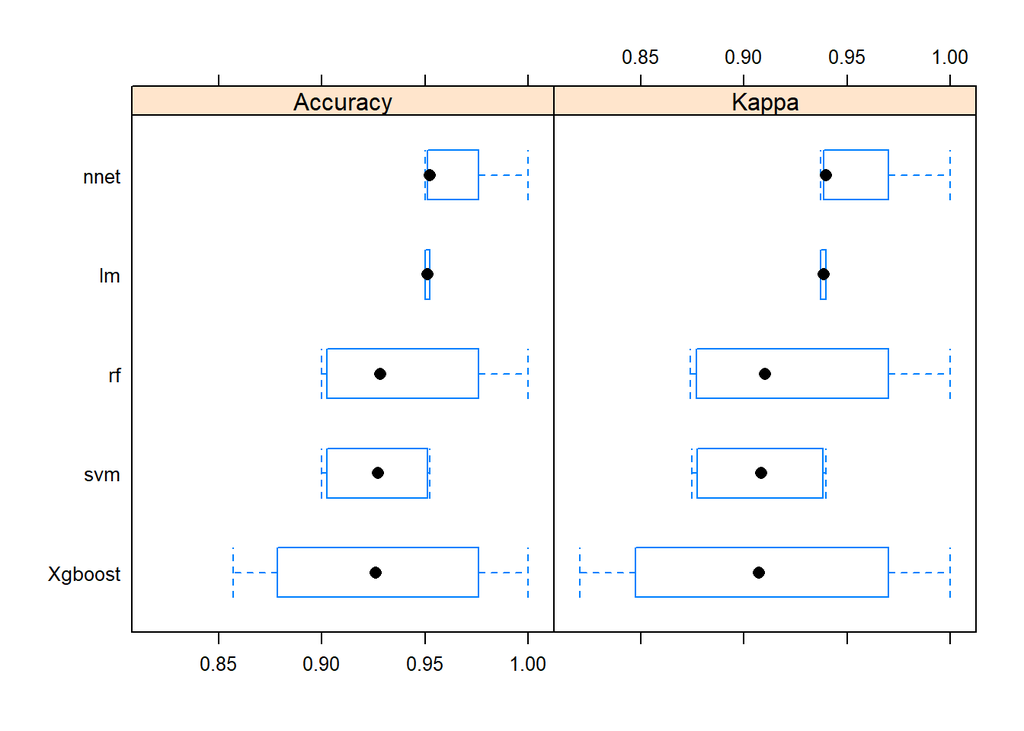

```r
## Keep models in a list
list_model_B <- list("lm" = model_lm$train_mod,
                      "nnet" = model_nn$train_mod,
                      "rf" = model_rf$train_mod,
                      "Xgboost" = model_xgb$train_mod,
                      "svm" = model_svm$train_mod)

## Plot performances of prediction model
model_B <- caret::resamples(list_model_B)
bwplot(model_B)
```

```r
## Probabilities of belonging to each category for the mass spectra on test set
prob_cat=MSclassifR::Predict_LogReg(peaks = peaks[-Index_skfold],
                                    model = list_model_B,
                                    moz = sel_moz)
```

```r
## Split table according method used
ResultatsModelB <- split(prob_cat,prob_cat$method)

## Calcul accuracy for each method
DF_B <- data.frame(lapply(ResultatsModelB, function(x)(sum(Y_testb == x[,8])/length(Y_testb))), row.names = "RFEGlmnet accuracy")

t(DF_B)
```

```
##             RFEGlmnet accuracy
## comb_fisher          0.2857143
## max_vote             0.2857143
## multinom             1.0000000
## nnet                 1.0000000
## rf                   0.9285714
## svmLinear2           0.4285714
## xgbTree              0.7857143
```

### 7.3 Use the selected variables with sPLSDA method

```r
## Select variables found with RFGlmnet
sel_moz=c$sel_moz

## linear multinomial regression
model_lm=MSclassifR::LogReg(X=X_train, moz=sel_moz, Y=factor(Y_train), number=2, repeats=2)
#Estimated model:
#model_lm

## nonlinear multinomial regression using neural networks
model_nn=MSclassifR::LogReg(X=X_train, moz=sel_moz, Y=factor(Y_train), number=2, repeats=2, kind="nnet")
#Estimated model:
#model_nn

## nonlinear multinomial regression using random forests
model_rf=MSclassifR::LogReg(X=X_train, moz=sel_moz, Y=factor(Y_train), number=2, repeats=2, kind="rf")
#Estimated model:
#model_rf

## nonlinear multinomial regression using xgboost
model_xgb=MSclassifR::LogReg(X=X_train, moz=sel_moz, Y=factor(Y_train), number=2, repeats=2, kind="xgb")
#Estimated model:
#model_xgb

## nonlinear multinomial regression using svm
model_svm=MSclassifR::LogReg(X=X_train, moz=sel_moz, Y=factor(Y_train), number=2, repeats=2, kind="svm")
#Estimated model:
#model_svm
```

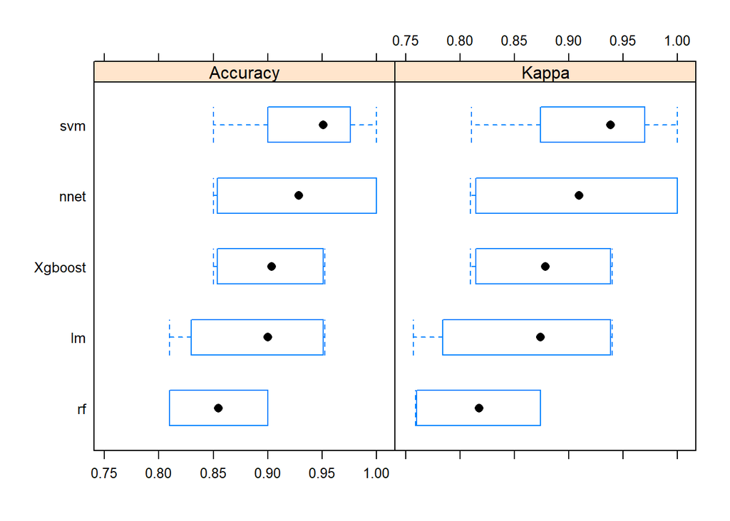

```r
## Keep models in a list
list_model_C <- list("lm" = model_lm$train_mod,
                      "nnet" = model_nn$train_mod,
                      "rf" = model_rf$train_mod,
                      "Xgboost" = model_xgb$train_mod,
                      "svm" = model_svm$train_mod)

## Plot performances of prediction model
model_C <- caret::resamples(list_model_C)
bwplot(model_C)
```

```r
## Probabilities of belonging to each category for the mass spectra on test set
prob_cat=MSclassifR::Predict_LogReg(peaks = peaks[-Index_skfold],
                                    model = list_model_C,
                                    moz = sel_moz)
```

```r
## Split table according method used
ResultatsModelC <- split(prob_cat,prob_cat$method)

## Calcul accuracy for each method
DF_C <- data.frame(lapply(ResultatsModelC, function(x)(sum(Y_testb == x[,8])/length(Y_testb))), row.names = "sPLSDA accuracy")

t(DF_C)
```

```
##             sPLSDA accuracy
## comb_fisher       0.2857143
## max_vote          0.2142857
## multinom          1.0000000
## nnet              1.0000000
## rf                1.0000000
## svmLinear2        0.2857143
## xgbTree           0.7857143
```

### 7.4 Use the selected variables with VSURF method

```r
## Select variables found with RFGlmnet
sel_moz=d$sel_moz

## linear multinomial regression
model_lm=MSclassifR::LogReg(X=X_train, moz=sel_moz, Y=factor(Y_train), number=2, repeats=2)
#Estimated model:
#model_lm

## nonlinear multinomial regression using neural networks
model_nn=MSclassifR::LogReg(X=X_train, moz=sel_moz, Y=factor(Y_train), number=2, repeats=2, kind="nnet")
#Estimated model:
#model_nn

## nonlinear multinomial regression using random forests
model_rf=MSclassifR::LogReg(X=X_train, moz=sel_moz, Y=factor(Y_train), number=2, repeats=2, kind="rf")
#Estimated model:
#model_rf

## nonlinear multinomial regression using xgboost
model_xgb=MSclassifR::LogReg(X=X_train, moz=sel_moz, Y=factor(Y_train), number=2, repeats=2, kind="xgb")
#Estimated model:
#model_xgb

## nonlinear multinomial regression using svm
model_svm=MSclassifR::LogReg(X=X_train, moz=sel_moz, Y=factor(Y_train), number=2, repeats=2, kind="svm")
#Estimated model:
#model_svm
```

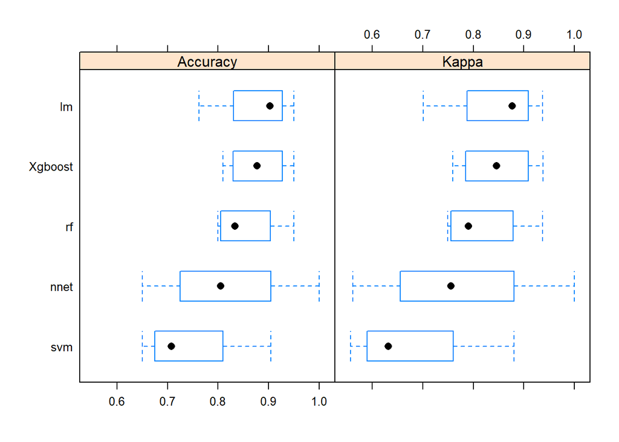

```r
## Keep models in a list
list_model_D <- list("lm" = model_lm$train_mod,
                      "nnet" = model_nn$train_mod,
                      "rf" = model_rf$train_mod,
                      "Xgboost" = model_xgb$train_mod,
                      "svm" = model_svm$train_mod)

## Plot performances of prediction model
model_D <- caret::resamples(list_model_D)
bwplot(model_D)
```

```r
## Probabilities of belonging to each category for the mass spectra on test set
prob_cat=MSclassifR::Predict_LogReg(peaks = peaks[-Index_skfold],
                                    model = list_model_D,
                                    moz = as.numeric(sel_moz))
```

```r
## Split table according method used
ResultatsModelD <- split(prob_cat,prob_cat$method)

## Calcul accuracy for each method
DF_D <- data.frame(lapply(ResultatsModelC, function(x)(sum(Y_testb == x[,8])/length(Y_testb))), row.names = "VSURF accuracy")

t(DF_D)
```

```
##             VSURF accuracy
## comb_fisher      0.2857143
## max_vote         0.2142857
## multinom         1.0000000
## nnet             1.0000000
## rf               1.0000000
## svmLinear2       0.2857143
## xgbTree          0.7857143
```

## 8. Conclusion

the accuracies of all the used method in the test dataset can be summarized:

```r
## Summarize results on test set
DFf <- rbind(DF_A, DF_B, DF_C, DF_D)

## Print results
t(DFf)
```

```
##             RFERF accuracy RFEGlmnet accuracy sPLSDA accuracy VSURF accuracy
## comb_fisher     0.21428571          0.2857143       0.2857143      0.2857143
## max_vote        0.28571429          0.2857143       0.2142857      0.2142857
## multinom        0.85714286          1.0000000       1.0000000      1.0000000
## nnet            0.85714286          1.0000000       1.0000000      1.0000000
## rf              1.00000000          0.9285714       1.0000000      1.0000000
## svmLinear2      0.07142857          0.4285714       0.2857143      0.2857143
## xgbTree         0.85714286          0.7857143       0.7857143      0.7857143
```

```r
## time measurement
end_time <- Sys.time()
end_time - start_time
```

```
## Time difference of 48.34758 mins
```

## References

Genuer,R. *et al.* (2015) [VSURF: An R Package for Variable Selection Using Random Forests](https://hal.archives-ouvertes.fr/hal-01251924). *The R Journal*, **7**, 19–33.

Gibb,S. and Strimmer,K. (2012) [MALDIquant: a versatile R package for the analysis of mass spectrometry data](https://doi.org/10.1093/bioinformatics/bts447). *Bioinformatics*, **28**, 2270–2271.

Kuhn,M. (2008) [Building predictive models in r using the caret package](https://doi.org/10.18637/jss.v028.i05). *Journal of Statistical Software, Articles*, **28**, 1–26.

Lasch,P. *et al.* (2016) [A MALDI-TOF Mass Spectrometry Database for Identification and Classification of Highly Pathogenic Microorganisms from the Robert Koch- Institute (RKI)](https://doi.org/10.5281/zenodo.163517).

Rohart F,G.B. *et al.* (2017) [mixOmics: An r package for ’omics feature selection and multiple data integration](http://www.mixOmics.org). *PLoS computational biology*, **13**, e1005752.

Wilke,T. *et al.* (2020) [Proteomic Fingerprinting Discriminates Cryptic Gastropod Species](https://doi.org/10.4002/040.063.0113). *Malacologia*, **63**, 131–137.